# Validating a Widely Implemented Deterioration Index Model Among Hospitalized COVID-19 Patients

# Setup

```r
library(tidyverse)
library(tidymodels)
library(readxl)
library(janitor)
library(ggeasy)
library(lubridate)
library(slider)
library(patchwork)
# library(tidylog)
```

# Define a function to generate threshold versus performance plots

We will use this to generate Figures 1 and 3.

This is based on the `threshold_perf()` function from the `probably` package (a part of `tidymodels`) but expands the capability to allow for the range of metrics we can use to include positive and negative predictive value.

```r
threshold_perf_2 = function (.data, truth, estimate, thresholds = NULL, na_rm = TRUE,
  ...)
{
  if (is.null(thresholds)) {
    thresholds <- seq(0.5, 1, length = 21)
  }
  nms <- names(.data)
  obs <- tidyselect::vars_select(nms, !!enquo(truth))
  probs <- tidyselect::vars_select(nms, !!enquo(estimate))
  rs_ch <- dplyr::group_vars(.data)
  rs_ch <- unname(rs_ch)
  obs_sym <- sym(obs)
  probs_sym <- sym(probs)
  if (length(rs_ch) == 0) {
    rs_ch <- NULL
    rs_id <- NULL
  }
  else {
    rs_id <- syms(rs_ch)
  }
  if (length(probs) > 1 | length(obs) > 1)
    stop("`truth` and `estimate` should only be single columns.",
      call. = FALSE)
  if (!inherits(.data[[obs]], "factor"))
    stop("`truth` should be a factor", call. = FALSE)
  if (length(levels(.data[[obs]])) != 2)
    stop("`truth` should be a 2 level factor", call. = FALSE)
  if (!is.numeric(.data[[probs]]))
    stop("`estimate` should be numeric", call. = FALSE)
  .data <- dplyr::rename(.data, truth = !!obs_sym, prob = !!probs_sym)
  if (!is.null(rs_id)) {
    .data <- dplyr::select(.data, truth, prob, !!!rs_id)
  }
  else {
    .data <- dplyr::select(.data, truth, prob)
  }
  if (na_rm) {
    .data <- na.omit(.data)
  }
  .data <- .data %>% probably:::expand_preds(threshold = thresholds,
    inc = c("truth", "prob", rs_ch)) %>% mutate(alt_pred = probably:::recode_data(truth,
    prob, .threshold))
  if (!is.null(rs_id)) {
    .data <- .data %>% group_by(!!!rs_id, .threshold)
  }
  else {
    .data <- .data %>% group_by(.threshold)
  }
  .data_metrics <- .data %>% two_class(truth, estimate = alt_pred)
  sens_vec <- .data_metrics %>% dplyr::filter(.metric == "sens") %>%
    dplyr::pull(.estimate)
  dist <- .data_metrics %>% dplyr::filter(.metric == "spec") %>%
    dplyr::mutate(.metric = "distance", .estimate = (1 -
      sens_vec)^2 + (1 - .estimate)^2)
  .data_metrics <- dplyr::bind_rows(.data_metrics, dist)
  .data_metrics
}

two_class = function (...){
  mets <- metric_set(sens, spec, j_index, accuracy, bal_accuracy, ppv, npv)
  mets(...)
}
```

# Define a function to generate the calibration curve

We will use this function to generate Figure 2. The cal_plot() function below is a modified version of the function displayed on this GitHub page here (https://darrendahly.github.io/post/homr/). The original function was authored by Darren Dahly, PhD and is partially based on Frank Harrell, PhD’s `rms` package.

```r
  cal_plot <- function(data, pred_var,model_name,...){

    require(tidyverse)
    require(viridis)
    require(gridExtra)

# The calibration plot
    g1 <- mutate(data, bin = ntile(get(pred_var), 5)) %>%
          # Bin prediction into 5ths
      group_by(bin) %>%
      mutate(n = n(), # Get ests and CIs
             bin_pred = mean(get(pred_var)),
             bin_prob = mean(as.numeric(outcome)),
             se = sqrt((bin_prob * (1 - bin_prob)) / n),
             ul = bin_prob + 1.96 * se,
             ll = bin_prob - 1.96 * se) %>%
      ungroup() %>%
    ggplot(aes(x = bin_pred, y = bin_prob, ymin = ll, ymax = ul)) +
      geom_pointrange(size = 0.5, color = "black") +
      scale_y_continuous(limits = c(0, 1), breaks = seq(0, 1, by = 0.1)) +
      scale_x_continuous(limits = c(0, 1), breaks = seq(0, 1, by = 0.1)) +
      geom_abline() + # 45 degree line indicating perfect calibration
      geom_smooth(method = "lm", se = FALSE, linetype = "dashed",
                  color = "black", formula = y~-1 + x) +
                  # straight line fit through estimates
      # geom_smooth(aes(x = get(pred_var), y = as.numeric(outcome)),
      #            color = "red", se = FALSE, method = "loess") +
                  # loess fit through estimates
      xlab("Predicted Epic Deterioration Index, Rescaled 0 to 1") +
      ylab("Observed Risk") +
      theme_minimal() +
      ggtitle(model_name)

# The distribution plot
    g2 <- ggplot(data, aes(x = get(pred_var))) +
      geom_histogram(fill = "black", bins = 200) +
      scale_x_continuous(limits = c(0, 1), breaks = seq(0, 1, by = 0.1)) +
      xlab("") +
      ylab("") +
      theme_minimal() +
      easy_remove_y_axis() +
      easy_remove_x_axis() +
      theme_void()

      g2 / g1 + plot_layout(heights = c(1,10))

  }
```

# Load the data

```r
excel_sheets('Snapshot Apr 7 v3.xlsx')
```

```
[1] "COVID19 INF" "AD"          "Transfers"   "VentData"
```

```r
covid_inf = read_excel('Snapshot Apr 7 v3.xlsx', 1, na = '(null)') %>% distinct()
covid_ad = read_excel('Snapshot Apr 7 v3.xlsx', 2, na = '(null)') %>% distinct()
covid_transfers = read_excel('Snapshot Apr 7 v3.xlsx', 3, na = '(null)') %>% distinct()
covid_vent = read_excel('Snapshot Apr 7 v3.xlsx', 4, na = '(null)') %>% distinct()

covid_ad =
  covid_ad %>%
  filter(HOSP_ADMSN_TIME >= lubridate::mdy('3-9-2020'))

covid_transfers =
  covid_transfers %>%
  filter(START_TIME >= lubridate::mdy('3-9-2020'))

covid_vent = covid_vent %>% arrange(PAT_ENC_CSN_ID,RECORDED_TIME)

covid_transfers =
  covid_transfers %>%
  arrange(PAT_ENC_CSN_ID, SEQ_NUM_IN_ENC)

epic_di = read_csv('March7_April6_DIScores.csv')
epic_di = epic_di %>%
  mutate(RECORDED_TIME = lubridate::dmy_hms(RECORDED_TIME)) %>%
  rename(SCORE_TIME = RECORDED_TIME) %>%
  rename(MODEL_SCORE = DI_SCORE) %>%
  mutate(MODEL_TYPE = 'Epic DI score') %>%
  select(PAT_ENC_CSN_ID, SCORE_TIME, MODEL_SCORE, MODEL_TYPE) %>%
  filter(PAT_ENC_CSN_ID %in% covid_ad$PAT_ENC_CSN_ID) %>%
  filter(SCORE_TIME >= lubridate::mdy('3-9-2020'))

covid_cohort = read_csv('covid_cohort_outcomes_20200408.csv')
```

# For patients who experience an adverse outcome, remove all EDI predictions that occur at or after the time of the adverse outcome

```r
epic_di_filter_time =
  inner_join(epic_di, covid_cohort) %>%
  mutate(OUTCOME_TIME = pmin(ICU_STATUS_TIME, VENT_START_TIME, na.rm=TRUE) %>% pmin(ED_OR_FLOOR_TO_ICU_TIME, na.rm=TRUE) %>% pmin(DIED_OR_HOSPICE_TIME,na.rm=TRUE)) %>%
  filter(is.na(OUTCOME_TIME) | SCORE_TIME < OUTCOME_TIME) %>%
  select(1:4, OUTCOME_TIME)
```

# Generate a composite outcome for ICU status or vent or ICU transfer

- For requirement of ICU-level care, we will take the first of: status changed to ICU status OR physically transferred from floor to ICU
- Exclude actively admitted patients (who have not had an event)
- Since we only have timestamps for events, we will use the latest timestamp to determine the length of follow-up for actively admitted patients
- Remove hospice DC from outcomes list, thus:
  - Even though the variable is called DIED_OR_HOSPICE_TIME, it only includes death (because hospice patients have been excluded)

```r
latest_timestamp =
  covid_cohort %>%
  summarize_at(vars(HOSP_ED_ROOMED_OR_TRANSFER_TIME,
         ADMIT_TIME, ED_TO_FLOOR_TIME,
         ICU_STATUS_TIME,
         ED_OR_FLOOR_TO_ICU_TIME,
         VENT_START_TIME,
         VENT_FINAL_STOP_TIME,
         DIED_OR_HOSPICE_TIME,
         DC_TIME), . %>% max(na.rm=TRUE)) %>%
  gather() %>%
  summarize(value = max(value)) %>%
  pull(value)

covid_cohort_study =
  covid_cohort %>%
  mutate(OUTCOME = if_else(!is.na(VENT_START_TIME) | !is.na(ICU_STATUS_TIME) | !is.na(ED_OR_FLOOR_TO_ICU_TIME) | !is.na(DIED_OR_HOSPICE_TIME), 'ICU_OR_VENT_OR_DEATH', 'NO_OUTCOME')) %>%
  mutate(OUTCOME_TIME = pmin(ICU_STATUS_TIME, VENT_START_TIME, na.rm=TRUE) %>% pmin(ED_OR_FLOOR_TO_ICU_TIME, na.rm=TRUE) %>% pmin(DIED_OR_HOSPICE_TIME,na.rm=TRUE)) %>%
  filter(ADMIT_LEVEL_OF_CARE != 'ICU') %>%
  filter(DC_DISP != '16 Hospice/Home' | is.na(DC_DISP)) %>%
  filter(!is.na(DC_TIME) | !is.na(OUTCOME_TIME))
```

# Create cohort for use of continuous EDI score to predict composite adverse outcomes that occur during the hospitalization

This will be useful for evaluating the ability of the EDI to identify high-risk patients

```r
# There are a total of 182 patients
covid_cohort_study %>%
  count(OUTCOME) %>%
  mutate(prop = n/sum(n))
```

| OUTCOME | n | prop |
| --- | --- | --- |
| ICU_OR_VENT_OR_DEATH | 68 | 0.3736264 |
| NO_OUTCOME | 114 | 0.6263736 |

```r
covid_di_study_scores =
  epic_di_filter_time %>%
  inner_join(covid_cohort_study) %>%
  arrange(PAT_ENC_CSN_ID, SCORE_TIME) %>%
  group_by(PAT_ENC_CSN_ID) %>%
  ungroup()
covid_di_study =
  epic_di_filter_time %>%
  inner_join(covid_cohort_study) %>%
  arrange(PAT_ENC_CSN_ID, SCORE_TIME) %>%
  group_by(PAT_ENC_CSN_ID) %>%
  filter(MODEL_SCORE == max(MODEL_SCORE)) %>%
  slice(1) %>%
  ungroup()
# After removing the 8 patients without EDI scores, we are left with 174 patients
covid_di_study %>% count(OUTCOME) %>% mutate(prop = n/sum(n))
```

| OUTCOME | n | prop |
| --- | --- | --- |
| ICU_OR_VENT_OR_DEATH | 61 | 0.3505747 |
| NO_OUTCOME | 113 | 0.6494253 |

# When does EDI start scoring patients (in hours) with respect to their admission time?

For 3 patients, their first EDI was calculated >1 hour prior to admission. For all others, it was calculated very close to the time of admission.

```r
covid_di_study_scores %>%
  group_by(PAT_ENC_CSN_ID) %>%
  filter(SCORE_TIME == min(SCORE_TIME)) %>%
  ungroup() %>%
  mutate(DIFF_SCORE = as.numeric(difftime(SCORE_TIME, ADMIT_TIME, units = 'hours'))) %>%
  arrange(DIFF_SCORE) %>%
  select(DIFF_SCORE) %>%
  head()
```

| DIFF_SCORE |
| --- |
| -16.1166667 |
| -2.5666667 |
| -1.3500000 |
| -0.8833333 |
| -0.8166667 |
| -0.7666667 |

```r
covid_di_study_scores %>%
  group_by(PAT_ENC_CSN_ID) %>%
  filter(SCORE_TIME == min(SCORE_TIME)) %>%
  ungroup() %>%
  mutate(DIFF_SCORE = as.numeric(difftime(SCORE_TIME, ADMIT_TIME, units = 'hours'))) %>%
  arrange(DIFF_SCORE) %>%
  select(DIFF_SCORE) %>%
  summary()
```

```
   DIFF_SCORE
 Min.   :-16.11667
 1st Qu.:  0.01667
 Median :  0.08333
 Mean   : -0.04435
 3rd Qu.:  0.15000
 Max.   :  1.80000
```

# When did the events occur following admission (in hours for plot and in days for summary)?

```r
admit_to_outcome_plot = covid_di_study %>%
  mutate(DIFF_TIME = difftime(OUTCOME_TIME, ADMIT_TIME, units='hours')) %>%
  ggplot(aes(x = DIFF_TIME)) +
  geom_density(fill = 'lightblue') +
  theme_bw() +
  labs(x = 'Hours between admission and adverse outcomes' , y = 'Density')

covid_di_study %>%
  mutate(DIFF_TIME = as.numeric(difftime(OUTCOME_TIME, ADMIT_TIME, units='days'))) %>%
  select(DIFF_TIME) %>%
  arrange(DIFF_TIME) %>%
  summary()
```

```
   DIFF_TIME
 Min.   : 0.00139
 1st Qu.: 0.54792
 Median : 1.32569
 Mean   : 2.37507
 3rd Qu.: 3.49514
 Max.   :10.47569
 NA's   :113
```

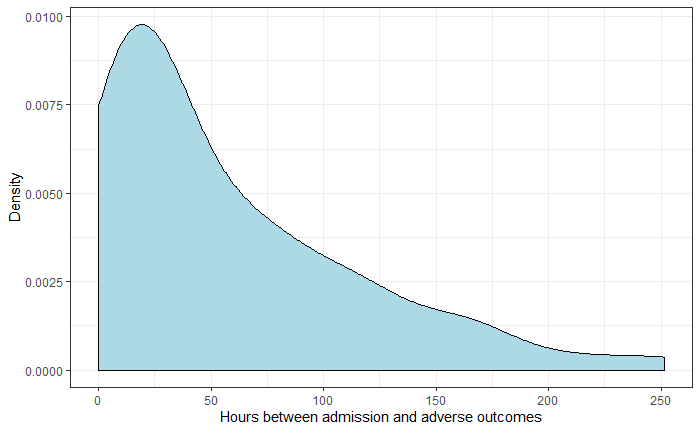

```r
admit_to_outcome_plot
```

```r
# ggsave('admit_to_outcome_plot_202020409.jpg', admit_to_outcome_plot, width = 10, height = 10, units = 'in', dpi = 320, scale = 0.5)
```

# Compare the distribution of maximum model predictions in those who did and did not experience the outcome

We are focusing on the maximum achieved score because we consider patients as high-risk if they **ever** meet or exceed an EDI threshold (for every possible threshold).

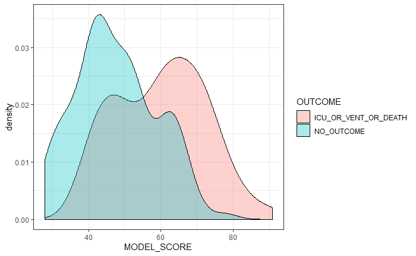

```r
covid_di_study_scores %>%
  group_by(PAT_ENC_CSN_ID) %>%
  summarize(MODEL_SCORE = max(MODEL_SCORE), OUTCOME = first(OUTCOME)) %>%
  ggplot(aes(x=MODEL_SCORE, fill = OUTCOME)) +
  geom_density(alpha = 1/3) +
  theme_bw()
```

# Using the maximum EDI score for each patient, calculate the AUC

```r
# Max
set.seed(1)
covid_di_study_scores %>%
  arrange(SCORE_TIME) %>%
  group_by(PAT_ENC_CSN_ID) %>%
  summarize(MODEL_SCORE = max(MODEL_SCORE), OUTCOME = first(OUTCOME)) %>%
  mutate(OUTCOME = as.factor(OUTCOME) %>% fct_rev()) %>%
  pROC::roc(OUTCOME, MODEL_SCORE, ci=TRUE, ci.method='bootstrap',
              boot.n = 1000, boot.stratified = FALSE)
```

```
Call:
roc.data.frame(data = ., response = OUTCOME, predictor = MODEL_SCORE,     ci = TRUE, ci.method = "bootstrap", boot.n = 1000, boot.stratified = FALSE)

Data: MODEL_SCORE in 113 controls (OUTCOME NO_OUTCOME) < 61 cases (OUTCOME ICU_OR_VENT_OR_DEATH).
Area under the curve: 0.7648
95% CI: 0.684-0.8354 (1000 non-stratified bootstrap replicates)
```

# Using the maximum slope (over the prior 4 and 8 hours), calculate the AUC

Since the score is calculated every 15 minutes (4 times per hour), we multiply 4 and 8 hours by 4 to capture the preceding 4 and 8 hours worth of EDI scores, respectively.

```r
for (i in 4 * c(4, 8)) {
  print(i)
  set.seed(1)
  covid_di_study_scores %>%
    group_by(PAT_ENC_CSN_ID) %>%
    mutate(ROLLING_LM = slide(MODEL_SCORE, ~lm(.x ~ row_number(.x)), .before = i)) %>%
    mutate(INTERCEPT = ROLLING_LM %>% map_dbl(. %>% broom::tidy() %>%
             filter(term == '(Intercept)') %>%
             pull(estimate))) %>%
    mutate(SLOPE = ROLLING_LM %>% map_dbl(. %>% broom::tidy() %>%
             filter(term == 'row_number(.x)') %>%
             {if (nrow(.) == 0) NA_real_ else .$estimate})) %>%
    summarize(SLOPE = max(SLOPE, na.rm = TRUE), OUTCOME = first(OUTCOME)) %>%
    filter(SLOPE != -Inf & SLOPE != Inf) %>%
    mutate(OUTCOME = as.factor(OUTCOME) %>% fct_rev()) %>%
    pROC::roc(OUTCOME, SLOPE, ci=TRUE, ci.method='bootstrap',
              boot.n = 1000, boot.stratified = FALSE) %>%
    print()
}
```

```
[1] 16
```

Results not displaying properly in HTML file so copy-pasting below:

```
[1] 16

Call:
roc.data.frame(data = ., response = OUTCOME, predictor = SLOPE,     ci = TRUE, ci.method = "bootstrap", boot.n = 1000, boot.stratified = FALSE)

Data: SLOPE in 113 controls (OUTCOME NO_OUTCOME) < 60 cases (OUTCOME ICU_OR_VENT_OR_DEATH).
Area under the curve: 0.6833
95% CI: 0.5997-0.7653 (1000 non-stratified bootstrap replicates)
[1] 32

Call:
roc.data.frame(data = ., response = OUTCOME, predictor = SLOPE,     ci = TRUE, ci.method = "bootstrap", boot.n = 1000, boot.stratified = FALSE)

Data: SLOPE in 113 controls (OUTCOME NO_OUTCOME) < 60 cases (OUTCOME ICU_OR_VENT_OR_DEATH).
Area under the curve: 0.6714
95% CI: 0.5903-0.7516 (1000 non-stratified bootstrap replicates)
```

# Generate ROC curve and precision-recall curve

```r
outcome_prop = covid_di_study %>%
  count(OUTCOME) %>%
  mutate(prop = n/sum(n)) %>%
  filter(OUTCOME == 'ICU_OR_VENT_OR_DEATH') %>%
  pull(prop)

covid_di_study_scores %>%
  group_by(PAT_ENC_CSN_ID) %>%
  summarize(MODEL_SCORE = max(MODEL_SCORE), OUTCOME = first(OUTCOME)) %>%
  roc_auc(truth = OUTCOME %>% as.factor(), MODEL_SCORE)
```

| .metric | .estimator | .estimate |
| --- | --- | --- |
| roc_auc | binary | 0.7647614 |

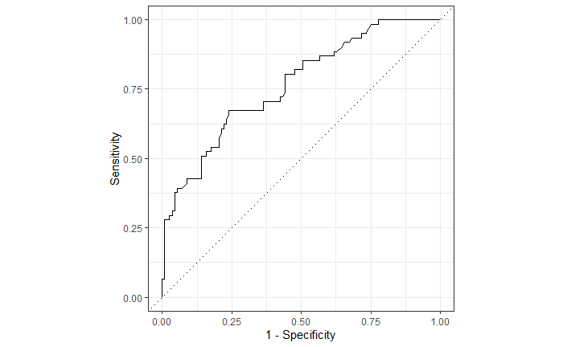

```r
roc_curve_plot = covid_di_study_scores %>%
  group_by(PAT_ENC_CSN_ID) %>%
  summarize(MODEL_SCORE = max(MODEL_SCORE), OUTCOME = first(OUTCOME)) %>%
  roc_curve(truth = OUTCOME %>% as.factor(), MODEL_SCORE) %>%
  autoplot() +
  labs(x = '1 - Specificity', y = 'Sensitivity')

roc_curve_plot
```

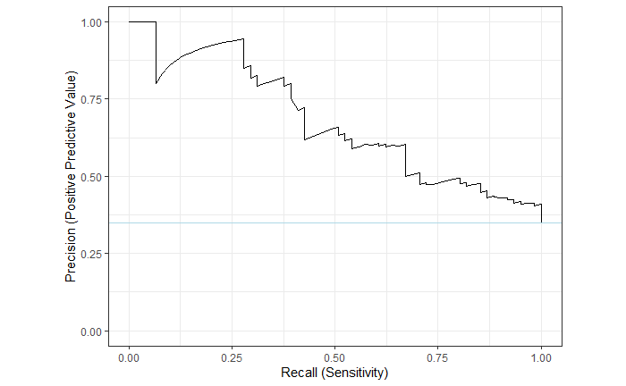

```r
# ggsave('roc_curve_plot_202020423.jpg', roc_curve_plot, width = 10, height = 10, units = 'in', dpi = 320, scale = 0.5)

pr_curve_plot = covid_di_study_scores %>%
  group_by(PAT_ENC_CSN_ID) %>%
  summarize(MODEL_SCORE = max(MODEL_SCORE), OUTCOME = first(OUTCOME)) %>%
  pr_curve(truth = OUTCOME %>% as.factor(), MODEL_SCORE) %>%
  autoplot() +
  geom_hline(yintercept = outcome_prop, color = 'lightblue') +
  labs(x = 'Recall (Sensitivity)', y = 'Precision (Positive Predictive Value)')

pr_curve_plot
```

```r
# ggsave('pr_curve_plot_202020423.jpg', pr_curve_plot, width = 10, height = 10, units = 'in', dpi = 320, scale = 0.5)
```

# Generate threshold vs. performance data for the primary analysis

```r
tp_data = covid_di_study_scores %>%
  group_by(PAT_ENC_CSN_ID) %>%
  summarize(MODEL_SCORE = max(MODEL_SCORE), OUTCOME = first(OUTCOME)) %>%
  mutate(OUTCOME = as.factor(OUTCOME)) %>%
  threshold_perf_2(truth = 'OUTCOME', MODEL_SCORE,thresholds = c(0,unique(.$MODEL_SCORE) %>% sort, 100))
```

# Figure 1: Plot threshold vs. performance

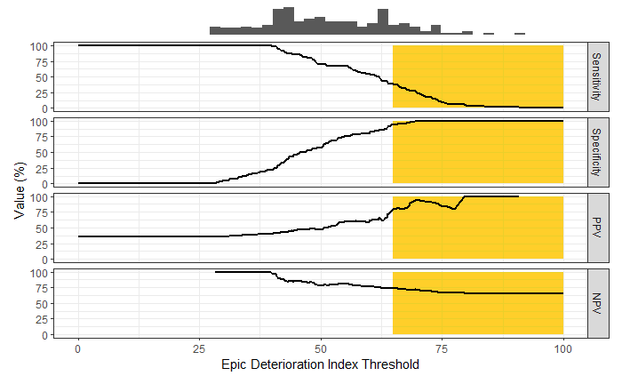

```r
tp_plot =
  tp_data %>%
  filter(!.metric %in% c('distance', 'j_index', 'bal_accuracy', 'accuracy')) %>%
  mutate(.metric = case_when(.metric == 'accuracy' ~ 'Accuracy',
    .metric == 'npv' ~ 'NPV',
    .metric == 'ppv' ~ 'PPV',
    .metric == 'spec' ~ 'Specificity',
    .metric == 'sens' ~ 'Sensitivity')) %>%
  mutate(.metric = fct_relevel(.metric, 'Sensitivity', 'Specificity', 'PPV', 'NPV')) %>%
  mutate(.estimate = .estimate * 100) %>%
  ggplot(aes(x = .threshold, y = .estimate)) +
  geom_rect(xmin = 64.8, ymin = 0, xmax = 100, ymax = 100, fill = 'orange', alpha = 1/100) +
  geom_line(size=1) +
  facet_grid(.metric~.) +
  theme_bw() +
  labs(x = 'Epic Deterioration Index Threshold', y = 'Value (%)')

threshold_dist_plot =
  covid_di_study_scores %>%
  group_by(PAT_ENC_CSN_ID) %>%
  summarize(MODEL_SCORE = max(MODEL_SCORE)) %>%
  ggplot(aes(x=MODEL_SCORE)) +
  geom_histogram() +
  coord_cartesian(xlim=c(0,100)) +
  theme_void()

# tp_plot %>%
#   plotly::ggplotly()

threshold_dist_plot / tp_plot + plot_layout(heights = c(1,10))
```

```r
# ggsave('tp_plot_20200424_2.jpg', width = 10, height = 10, units = 'in', dpi = 320, scale = 0.5)
```

# At EDI threshold >= 64.8, PPV is 80%

- Would flag 30 patients (17% of patients), 24 of whom experienced the outcome

```r
covid_di_study_scores %>%
  group_by(PAT_ENC_CSN_ID) %>%
  summarize(MODEL_SCORE = max(MODEL_SCORE), OUTCOME = first(OUTCOME)) %>%
  filter(MODEL_SCORE >= 64.8) %>%
  count(OUTCOME) %>%
  mutate(prop = n/sum(n))
```

| OUTCOME | n | prop |
| --- | --- | --- |
| ICU_OR_VENT_OR_DEATH | 24 | 0.8 |
| NO_OUTCOME | 6 | 0.2 |

```r
tp_data %>%
  filter(.threshold == 64.8)
```

| .threshold | .metric | .estimator | .estimate |
| --- | --- | --- | --- |
| 64.8 | sens | binary | 0.3934426 |
| 64.8 | spec | binary | 0.9469027 |
| 64.8 | j_index | binary | 0.3403453 |
| 64.8 | accuracy | binary | 0.7528736 |
| 64.8 | bal_accuracy | binary | 0.6701726 |
| 64.8 | ppv | binary | 0.8000000 |
| 64.8 | npv | binary | 0.7430556 |
| 64.8 | distance | binary | 0.3707312 |

```r
30/174
```

```
[1] 0.1724138
```

# How much lead time would we get with this threshold (between the time the threshold was first exceeded and the outcome)?

```r
covid_di_study_scores %>%
  arrange(SCORE_TIME) %>%
  group_by(PAT_ENC_CSN_ID) %>%
  filter(MODEL_SCORE >= 64.8) %>%
  slice(1) %>%
  ungroup() %>%
  mutate(LEAD_TIME = as.numeric(difftime(OUTCOME_TIME, SCORE_TIME, units='hours'))) %>%
  mutate(MEAN_LEAD_TIME = mean(LEAD_TIME, na.rm=TRUE)) %>%
  mutate(MEDIAN_LEAD_TIME = median(LEAD_TIME, na.rm=TRUE)) %>%
  mutate(TIME_AFTER_ADMIT = difftime(SCORE_TIME, ADMIT_TIME, units='hours')) %>%
  mutate(MEAN_ADMIT_TIME = mean(TIME_AFTER_ADMIT, na.rm=TRUE)) %>%
  mutate(MEDIAN_ADMIT_TIME = median(TIME_AFTER_ADMIT, na.rm=TRUE)) %>%
  select(OUTCOME, MODEL_SCORE, LEAD_TIME, MEAN_LEAD_TIME, MEDIAN_LEAD_TIME, TIME_AFTER_ADMIT, MEAN_ADMIT_TIME, MEDIAN_ADMIT_TIME) %>%
  arrange(LEAD_TIME) %>%
  select(LEAD_TIME) %>%
  summary()
```

```
   LEAD_TIME
 Min.   :  0.03333
 1st Qu.:  2.51250
 Median : 27.90000
 Mean   : 43.17778
 3rd Qu.: 68.97083
 Max.   :154.48333
 NA's   :6
```

# What is the length of follow-up in our study?

```r
los_plot = covid_di_study %>%
  mutate(LOS = if_else(is.na(DC_TIME) & is.na(DIED_OR_HOSPICE_TIME), difftime(latest_timestamp, ADMIT_TIME, units='days'), difftime(pmax(DC_TIME, DIED_OR_HOSPICE_TIME, na.rm=TRUE), ADMIT_TIME, units='days'))) %>%
  select(ADMIT_TIME, DC_TIME, LOS) %>%
  ggplot(aes(x=LOS)) +
  geom_density(fill='lightblue') +
  theme_bw() +
  labs(x = 'Length of Follow-up in Days', y = 'Density')

covid_di_study %>%
    mutate(LOS = if_else(is.na(DC_TIME) & is.na(DIED_OR_HOSPICE_TIME), difftime(latest_timestamp, ADMIT_TIME, units='days'), difftime(pmin(DC_TIME, DIED_OR_HOSPICE_TIME, na.rm=TRUE), ADMIT_TIME, units='days'))) %>%
  select(ADMIT_TIME, DC_TIME, LOS) %>%
  mutate(LOS = as.numeric(LOS)) %>%
  pull(LOS) %>% summary()
```

```
   Min. 1st Qu.  Median    Mean 3rd Qu.    Max.
 0.2597  2.6918  4.5483  5.9625  7.8026 25.2229
```

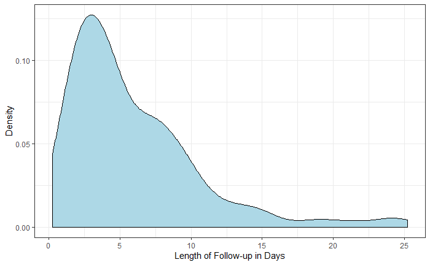

```r
los_plot
```

```r
# ggsave('los_plot_202020409.jpg', los_plot, width = 10, height = 10, units = 'in', dpi = 320, scale = 0.5)
```

# Figure 2: Calibration curve

This is generated based on all EDI predictions, not only the maximum EDI prediction.

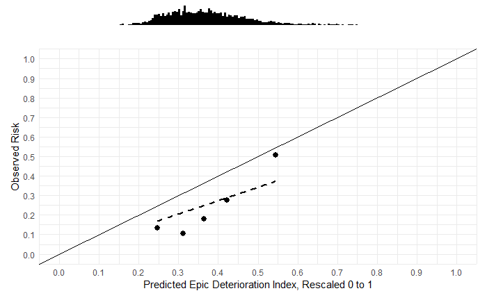

```r
covid_di_study_scores %>%
  mutate(outcome = if_else(OUTCOME == 'ICU_OR_VENT_OR_DEATH', 1, 0)) %>%
  mutate(MODEL_SCORE = MODEL_SCORE/100) %>%
  cal_plot(pred_var = 'MODEL_SCORE', model_name =  '')
```

```r
# ggsave('cal_plot_202020424_2.jpg', last_plot(), width = 10, height = 10, units = 'in', dpi = 320, scale = 0.5)
```

# What is the “average” EDI prediction across the cohort? How about the standard deviation?

```r
covid_di_study_scores %>% pull(MODEL_SCORE) %>%
  summary()
```

```
   Min. 1st Qu.  Median    Mean 3rd Qu.    Max.
  13.00   29.80   36.40   37.77   43.70   90.80
```

```r
covid_di_study_scores %>% pull(MODEL_SCORE) %>% sd()
```

```
[1] 10.92205
```

# How many patients experienced each outcome?

```r
covid_di_study %>%
  count(!is.na(ICU_STATUS_TIME))
```

| !is.na(ICU_STATUS_TIME) | n |
| --- | --- |
| FALSE | 114 |
| TRUE | 60 |

```r
covid_di_study %>%
  count(!is.na(ED_OR_FLOOR_TO_ICU_TIME))
```

| !is.na(ED_OR_FLOOR_TO_ICU_TIME) | n |
| --- | --- |
| FALSE | 136 |
| TRUE | 38 |

```r
covid_di_study %>%
  count(!is.na(ICU_STATUS_TIME) | !is.na(ED_OR_FLOOR_TO_ICU_TIME))
```

| !is.na(ICU_STATUS_TIME) \| !is.na(ED_OR_FLOOR_TO_ICU_TIME) | n |
| --- | --- |
| FALSE | 114 |
| TRUE | 60 |

```r
covid_di_study %>%
  count(!is.na(VENT_START_TIME))
```

| !is.na(VENT_START_TIME) | n |
| --- | --- |
| FALSE | 140 |
| TRUE | 34 |

```r
# covid_di_study %>%
#   count(DC_DISP)

covid_di_study %>%
  count(OUTCOME) %>%
  mutate(prop = n/sum(n))
```

| OUTCOME | n | prop |
| --- | --- | --- |
| ICU_OR_VENT_OR_DEATH | 61 | 0.3505747 |
| NO_OUTCOME | 113 | 0.6494253 |

# Generate cohort for 48-hour analysis (this is a subset of the original cohort)

Exclude all events and discharges prior to 48 hours.

```r
covid_di_study_scores_48h = covid_di_study_scores %>%
  filter(as.numeric(difftime(pmin(OUTCOME_TIME, DC_TIME, na.rm=TRUE),ADMIT_TIME, units = 'hours')) >= 48) %>%
  filter(as.numeric(difftime(SCORE_TIME,ADMIT_TIME, units='hours')) < 48)


# covid_di_study_scores_48h %>% distinct(PAT_ENC_CSN_ID) %>% count(PAT_ENC_CSN_ID)
#
covid_di_study_scores_48h %>% distinct(PAT_ENC_CSN_ID, OUTCOME) %>% count(OUTCOME) %>% ungroup() %>% mutate(prop = n/sum(n))
```

| OUTCOME | n | prop |
| --- | --- | --- |
| ICU_OR_VENT_OR_DEATH | 26 | 0.2385321 |
| NO_OUTCOME | 83 | 0.7614679 |

```r
set.seed(1)
covid_di_study_scores_48h %>%
  arrange(SCORE_TIME) %>%
  group_by(PAT_ENC_CSN_ID) %>%
  summarize(MODEL_SCORE = max(MODEL_SCORE), OUTCOME = first(OUTCOME)) %>%
  mutate(OUTCOME = as.factor(OUTCOME) %>% fct_rev()) %>%
  pROC::roc(OUTCOME, MODEL_SCORE, ci=TRUE, ci.method='bootstrap',
              boot.n = 1000, boot.stratified = FALSE)
```

```
Call:
roc.data.frame(data = ., response = OUTCOME, predictor = MODEL_SCORE,     ci = TRUE, ci.method = "bootstrap", boot.n = 1000, boot.stratified = FALSE)

Data: MODEL_SCORE in 83 controls (OUTCOME NO_OUTCOME) < 26 cases (OUTCOME ICU_OR_VENT_OR_DEATH).
Area under the curve: 0.6455
95% CI: 0.5189-0.7705 (1000 non-stratified bootstrap replicates)
```

# Total remaining length of follow-up for the 48-hour cohort

```r
covid_di_study_48h =
  covid_di_study_scores_48h %>%
  arrange(PAT_ENC_CSN_ID, SCORE_TIME) %>%
  group_by(PAT_ENC_CSN_ID) %>%
  filter(MODEL_SCORE == max(MODEL_SCORE)) %>%
  slice(1) %>%
  ungroup()

covid_di_study_48h %>%
    mutate(LOS = if_else(is.na(DC_TIME) & is.na(DIED_OR_HOSPICE_TIME), difftime(latest_timestamp, ADMIT_TIME, units='days'), difftime(pmin(DC_TIME, DIED_OR_HOSPICE_TIME, na.rm=TRUE), ADMIT_TIME, units='days'))) %>%
  select(ADMIT_TIME, DC_TIME, LOS) %>%
  mutate(LOS = as.numeric(LOS)) %>%
  mutate(LOS = LOS - 2) %>% # subtract out first 48 hours to calculate REMAINING length of follow-up
  pull(LOS) %>% summary()
```

```
   Min. 1st Qu.  Median    Mean 3rd Qu.    Max.
 0.1215  1.4646  2.9986  4.7736  5.8181 23.2229
```

# 48-hour analysis: Generate threshold vs. performance data

```r
tp_data_48h = covid_di_study_scores_48h %>%
  arrange(SCORE_TIME) %>%
  group_by(PAT_ENC_CSN_ID) %>%
  summarize(MODEL_SCORE = max(MODEL_SCORE), OUTCOME = first(OUTCOME)) %>%
  mutate(OUTCOME = as.factor(OUTCOME)) %>%
  threshold_perf_2(truth = 'OUTCOME', MODEL_SCORE,thresholds = c(0,unique(.$MODEL_SCORE) %>% sort, 100))
```

# Figure 3: Plot threshold vs performance for patients hospitalized for 48 hours who had not yet experienced the outcome

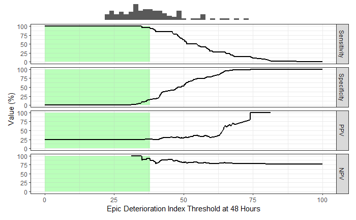

```r
tp_plot_48h =
  tp_data_48h %>%
  filter(!.metric %in% c('distance', 'j_index', 'bal_accuracy', 'accuracy')) %>%
  mutate(.metric = case_when(.metric == 'accuracy' ~ 'Accuracy',
    .metric == 'npv' ~ 'NPV',
    .metric == 'ppv' ~ 'PPV',
    .metric == 'spec' ~ 'Specificity',
    .metric == 'sens' ~ 'Sensitivity')) %>%
  mutate(.metric = fct_relevel(.metric, 'Sensitivity', 'Specificity', 'PPV', 'NPV')) %>%
  mutate(.estimate = .estimate * 100) %>%
  ggplot(aes(x = .threshold, y = .estimate)) +
  geom_rect(xmin = 0, ymin = 0, xmax = 37.9, ymax = 100, fill = 'lightgreen', alpha = 1/100) +
  geom_line(size=1) +
  facet_grid(.metric~.) +
  theme_bw() +
  labs(x = 'Epic Deterioration Index Threshold at 48 Hours', y = 'Value (%)')

threshold_dist_plot_48h =
  covid_di_study_scores_48h %>%
  arrange(SCORE_TIME) %>%
  group_by(PAT_ENC_CSN_ID) %>%
  summarize(MODEL_SCORE = last(MODEL_SCORE)) %>%
  ggplot(aes(x=MODEL_SCORE)) +
  geom_histogram() +
  coord_cartesian(xlim=c(0,100)) +
  theme_void()

# tp_plot_48h %>%
#   plotly::ggplotly()

threshold_dist_plot_48h / tp_plot_48h + plot_layout(heights = c(1,10))
```

```r
# ggsave('tp_plot_48h_20200424_2.jpg', width = 10, height = 10, units = 'in', dpi = 320, scale = 0.5)
```

# At values LESS THAN 37.9, NPV is 93%, sensitivity is 96%

Would flag 14 people out of a total of 109 in this 48-hour cohort (13%).

```r
covid_di_study_scores_48h %>%
  arrange(SCORE_TIME) %>%
  group_by(PAT_ENC_CSN_ID) %>%
  summarize(MODEL_SCORE = max(MODEL_SCORE), OUTCOME = first(OUTCOME)) %>%
  filter(MODEL_SCORE < 37.9) %>%
  pull(PAT_ENC_CSN_ID) ->
  low_risk_csns

covid_di_study_scores_48h %>%
  mutate(low_risk = PAT_ENC_CSN_ID %in% low_risk_csns) %>%
  distinct(low_risk,PAT_ENC_CSN_ID) %>%
  count(low_risk) %>%
  mutate(prop = n/sum(n))
```

| low_risk | n | prop |
| --- | --- | --- |
| FALSE | 95 | 0.8715596 |
| TRUE | 14 | 0.1284404 |

```r
tp_data_48h %>%
  filter(.threshold == 37.9)
```

| .threshold | .metric | .estimator | .estimate |
| --- | --- | --- | --- |
| 37.9 | sens | binary | 0.9615385 |
| 37.9 | spec | binary | 0.1566265 |
| 37.9 | j_index | binary | 0.1181650 |
| 37.9 | accuracy | binary | 0.3486239 |
| 37.9 | bal_accuracy | binary | 0.5590825 |
| 37.9 | ppv | binary | 0.2631579 |
| 37.9 | npv | binary | 0.9285714 |
| 37.9 | distance | binary | 0.7127581 |

# Figure 4: Four examples of the EDI score

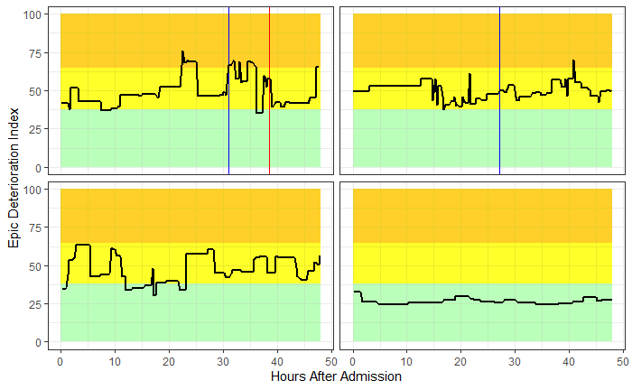

```r
figure_4_pat_enc_csn_id = read_csv('figure_4_pat_enc_csn_id.csv')
epic_plot =
  covid_di_study %>%
  filter(is.na(OUTCOME_TIME) | OUTCOME_TIME - ADMIT_TIME < hours(48)) %>%
  group_by(OUTCOME) %>%
  ungroup() %>%
  filter(PAT_ENC_CSN_ID %in% figure_4_pat_enc_csn_id$PAT_ENC_CSN_ID) %>%
  select(PAT_ENC_CSN_ID, ADMIT_TIME, ICU_STATUS_TIME, VENT_START_TIME, VENT_FINAL_STOP_TIME, DIED_OR_HOSPICE_TIME) %>%
  inner_join(epic_di) %>%
  mutate(SCORE_TIME = difftime(SCORE_TIME, ADMIT_TIME, units = 'hours') %>% as.numeric()) %>%
  filter(SCORE_TIME %>% between(0,48)) %>%
  mutate(PAT_ENC_CSN_ID = fct_rev(as.factor(PAT_ENC_CSN_ID))) %>%

  ggplot(aes(x=SCORE_TIME, y=MODEL_SCORE)) +
  geom_rect(xmin=0,xmax=48,ymin=0,ymax = 37.9, fill = 'lightgreen', alpha = 1/100) +
  geom_rect(xmin=0,xmax=48,ymin=37.9,ymax = 64.8, fill = 'yellow', alpha = 1/100) +
  geom_rect(xmin=0,xmax=48,ymin=64.8,ymax = 100, fill = 'orange', alpha = 1/100) +

  geom_vline(aes(xintercept =
                   difftime(ICU_STATUS_TIME, ADMIT_TIME, units= 'hours') %>% as.numeric()),
                 color = 'blue') +
  # geom_vline(aes(xintercept = ED_OR_FLOOR_TO_ICU_TIME), color = 'orange') +
  geom_vline(aes(xintercept =
                   difftime(VENT_START_TIME, ADMIT_TIME, units= 'hours') %>% as.numeric()),
                 color = 'red') +
  geom_vline(aes(xintercept =
                   difftime(VENT_FINAL_STOP_TIME, ADMIT_TIME, units='hours') %>% as.numeric()),
                 color = 'green') +
  geom_vline(aes(xintercept =
                   difftime(DIED_OR_HOSPICE_TIME, ADMIT_TIME, units= 'hours') %>% as.numeric()),
                 color = 'black') +

  geom_line(size =1) +
  facet_wrap(~PAT_ENC_CSN_ID) +
  coord_cartesian(ylim = c(0,100)) + xlim(0,48) +
  theme_bw() +
  labs(x = 'Hours After Admission',
       y = 'Epic Deterioration Index')  +
 theme(strip.text.x = element_blank())
epic_plot
```

```r
# ggsave('epic_plot_20200424_2.jpg', epic_plot,width = 10, height = 10, scale = 0.5, units = 'in', dpi = 320)
```